# Capstone_Project_AIML_Group1B_NLP_Final_Submission

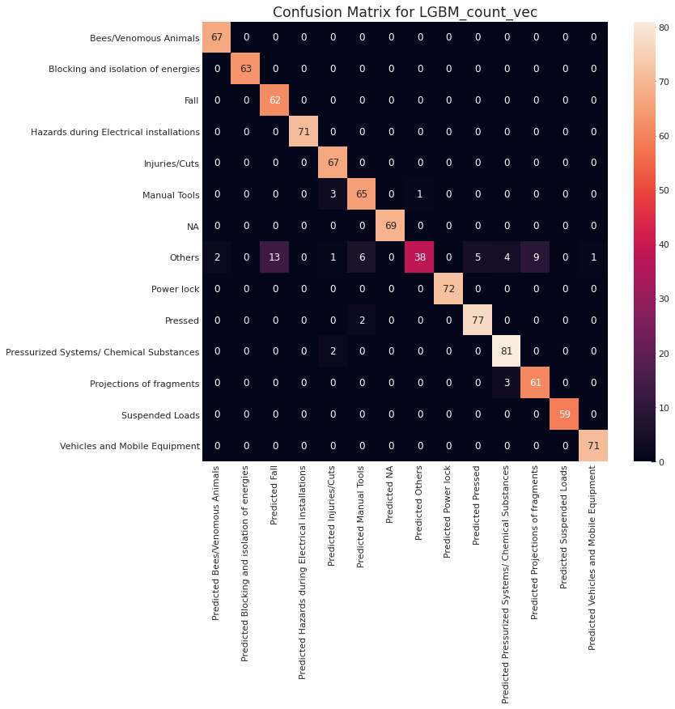

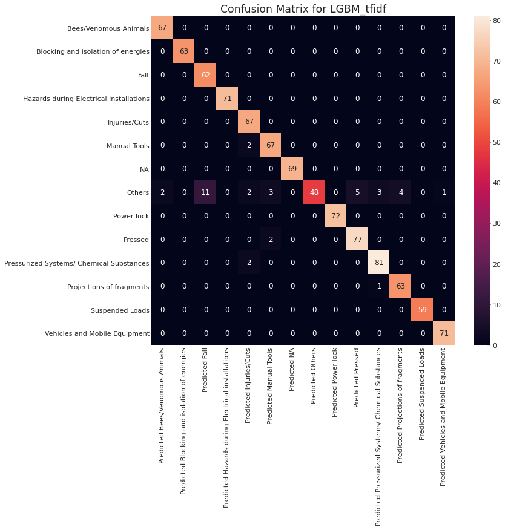

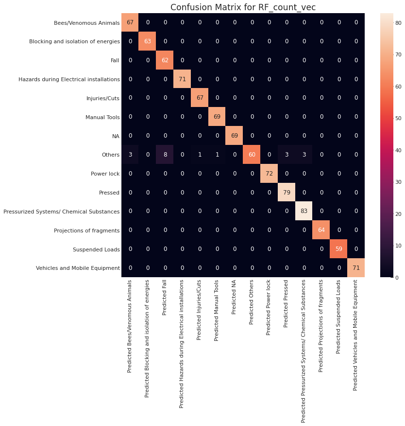

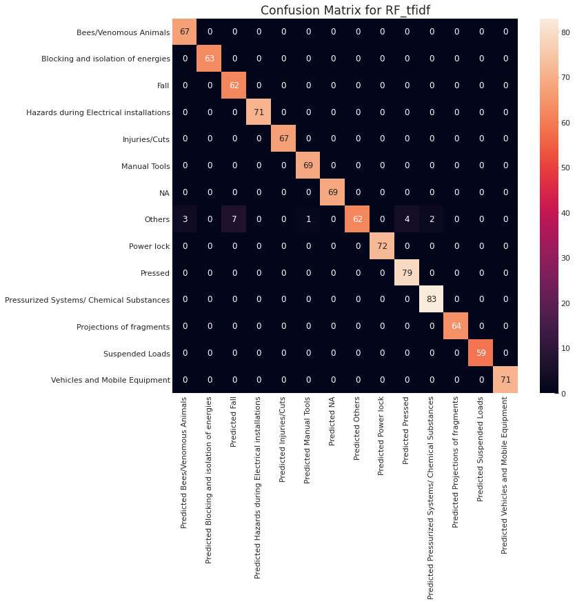

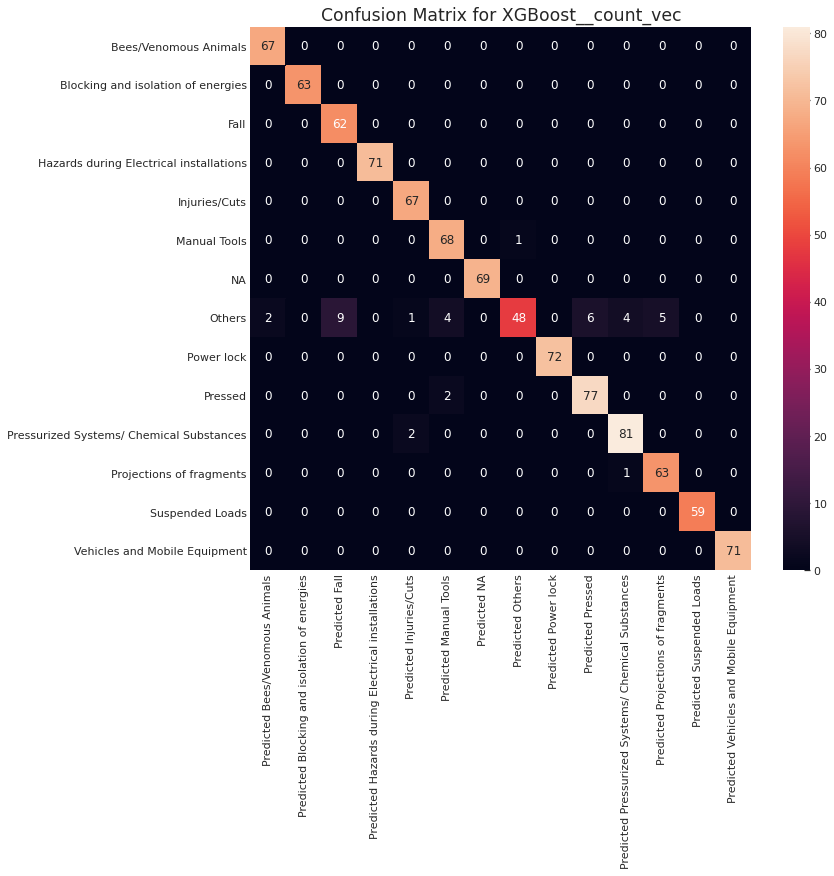

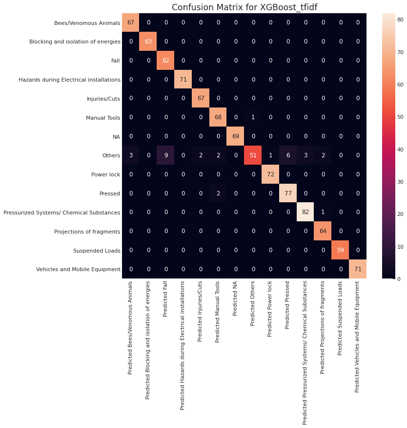

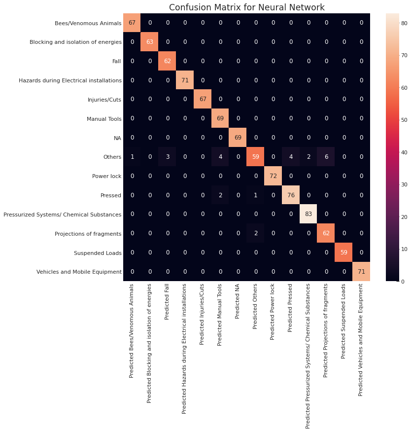

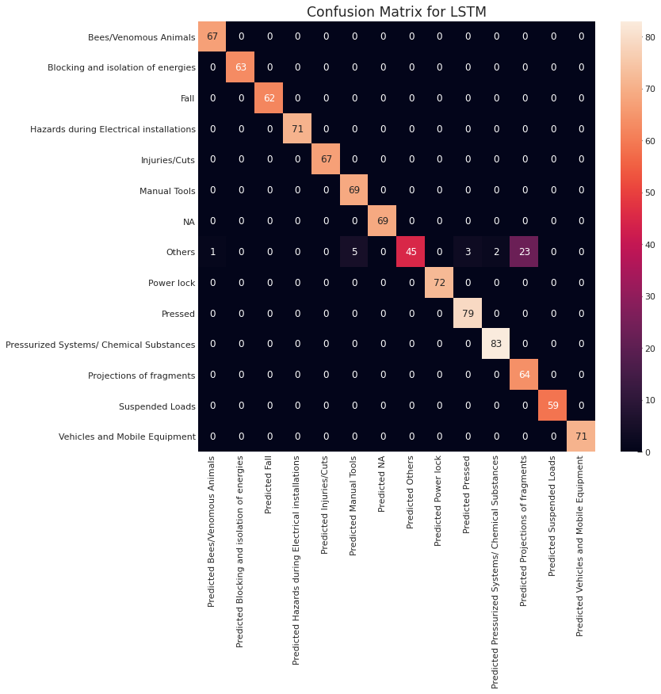

```python
model_df=[lgbm_countVec_act_pred, lgbm_tfidf_act_pred, rfc_countVec_act_pred, rfc_tfidf_act_pred, xgb_countVec_act_pred, xgb_tfidf_act_pred,df_NN,df_lstm]
models = ['LGBM_count_vec','LGBM_tfidf','RF_count_vec','RF_tfidf','XGBoost__count_vec','XGBoost_tfidf','Neural Network','LSTM']
for i in range(0,len(model_df)):
  j=model_df[i]
  conf_mat(j['Actual'],j['Predicted'],models[i])
```

# Final Thoughts

## Data:

- We discovered that the main causes of accidents are mistakes in hand-operation and time-related factor as evident by the bi-gram analysis.
- To reduce the occurrences of accidents, more stringent safety standards in hand-operation will be needed in period when many accidents occur. With more detailed information such as machining data(ex. CNC, Current, Voltage) in plants, weather information, employee's personal data(ex. age, experience in the industry sector, work performance ), we can clarify the cause of accidents more correctly.
- The data has inherent imbalance which in turn makes it difficult to predict the severity of incidents

## Model Finalization:

# Chat Bot UI

- Please refer to the gdrive link (link below) or the zip file shared to use flask based chatbot UI https://drive.google.com/file/d/1Qczd1CxlOi5pjCfmq0rPUVDauVQ5EvKw/view?usp=sharing

## Steps to Use the Chat Bot:

- For the python packages required to run the Flask app, please refer to the requirements.txt file in the root location.
- To run the chatbot application, open command prompt in the **root location of the Flask application** and run the command "python app.py". This file is there in the zip file mentioned above.
- Once the application starts, on the browser, open http://localhost:5000
- On the chatbot application, input the accident description in the text box provided to get the critical risk category , the mean accident level and the mean potential accident level. Some of the description is mentioned below.
- Typing "bye" in the text box ends the chat and shows a button "Chat again?" which can be clicked to continue the chat.

## Sample Input for chatbot:

- When averaging 04:30 am, the operator Daniel removed cleaning accessories under the mobile channel of line 01, for which he supported his left hand on the rail that was in motion. At that moment the crushing of the 2nd finger of the left hand occurs; the injury occurs. The collaborator is referred to the Medical for care.
- During the marking of the management points, the supervision and the breeders enter the work to carry out the ventilation inspection, for which the surveying work stops to turn on the fan and proceed with the air flow measurements. When the fan is turned on due to pressure, it breaks the fastening points of the toe and the sleeve falls to the floor generating a chicoteo from gable to gable, product of the chicoteo a fragment of the aggregate of the shocrete is projected on the face of the injure

### Please contact any of our team members for any confusion regarding the chatbot

## Chatbot UI Snapshot

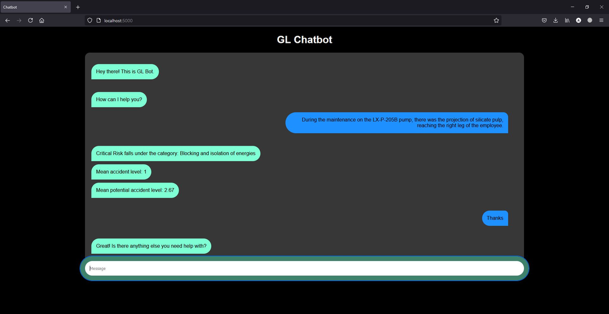

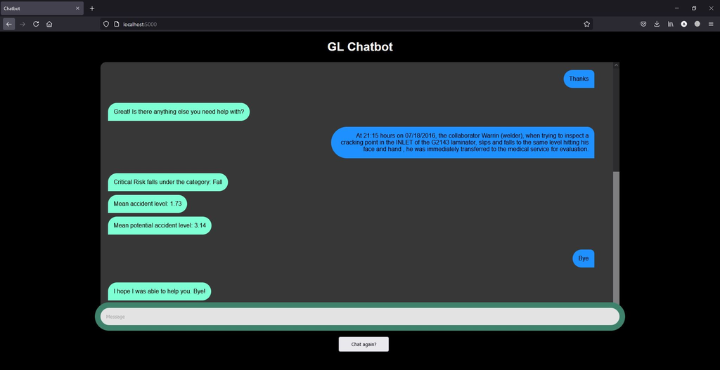

# References

- https://www.deepl.com/translator
- https://en.wikipedia.org/wiki/Glossary_of_chemical_formulae
- https://www.educative.io/edpresso/countvectorizer-in-python
- http://www.tfidf.com/
- https://pandas.pydata.org/
- https://mlfromscratch.com/
- https://ethen8181.github.io/machine-learning/clustering_old/tf_idf/tf_idf.html
- https://www.digitalocean.com/community
- https://www.investopedia.com/terms/c/chatbot.asp